# RA

### 15.2.4 Exercises

1. Create strings that contain the following values:

He said “That’s amazing!”

\\

```r
t1524 <- r"('He said "That's amazing!"'
"\a\b\c\d"
"\\\\\\")"
t1524
```

```
## [1] "'He said \"That's amazing!\"'\n\"\\a\\b\\c\\d\"\n\"\\\\\\\\\\\\\""
```

```r
str_view(t1524)
```

```
## [1] │ 'He said "That's amazing!"'
##     │ "\a\b\c\d"
##     │ "\\\\\\"
```

2. Create the string in your R session and print it. What happens to the special “0a0”? How does str_view() display it? Can you do a little googling to figure out what this special character is?

```r
x <- "This\u00a0is\u00a0tricky"
x
```

```
## [1] "This is tricky"
```

```r
str_view(x)
```

```
## [1] │ This{\u00a0}is{\u00a0}tricky
```

```r
#lets try
x <- c("This", "\u00a0", "is", "\u00a0", "tricky")
x
```

```
## [1] "This"   " "      "is"     " "      "tricky"
```

-“0a0” does not generate results, and it is NO-BREAK SPACE!

## 15.3 Creating many strings from data

### 15.3.1 str_c()

-str_c() takes any number of vectors as arguments and returns a character vector

```r
#If you want missing values to display in another way, use coalesce() to replace them. Depending on what you want, you might use it either inside or outside of str_c():
df <- tibble(name = c("Flora", "David", "Terra", NA))
df |>
  mutate(
    greeting1 = str_c("Hi ", coalesce(name, "you"), "!"),
    greeting2 = coalesce(str_c("Hi ", name, "!"), "Hi!")
  )
```

```
## # A tibble: 4 × 3
##   name  greeting1 greeting2
##   <chr> <chr>     <chr>
## 1 Flora Hi Flora! Hi Flora!
## 2 David Hi David! Hi David!
## 3 Terra Hi Terra! Hi Terra!
## 4 <NA>  Hi you!   Hi!
```

### 15.3.2 str_glue()

- str_glue() converts missing values to the string “NA”.

### 15.3.3 str_flatten()

- str_flatten() takes a character vector and combines each element of the vector into a single string, and work well with summarize()

### 15.3.4 Exercises

1.Compare and contrast the results of paste0() with str_c() for the following inputs:

```r
str_c("hi ", NA)
```

```
## [1] NA
```

```r
paste0("hi ", NA)
```

```
## [1] "hi NA"
```

```r
paste0(letters[1:2], letters[1:3])
```

```
## [1] "aa" "bb" "ac"
```

In the first case, paste9() treat NA as a string, and return “hi NA”. In the second case, In the second case, the str_c() cannot recycle the designated values in letters.

2. What’s the difference between paste() and paste0()? How can you recreate the equivalent of paste() with str_c()?

-?paste(), ?paste0() -paste0() is similar to paste(), but it has no separator. The return of paste0() will have no blank between values.

3. Convert the following expressions from str_c() to str_glue() or vice versa:

str_c(“The price of”, food, ” is “, price)

str_glue(“I’m {age} years old and live in {country}”)

str_c(“\section{”, title, “}”)

-food <- c(‘food’) -price <-c(‘price’) -age <- c(‘age’) -country <- c(‘country’)

-str_glue(“The price of {food} is {price}”)

-str_c(“I’m”, age, ” years old and live in “, country)

-str_glue(“\section{{{title}}}”)

## 15.4 Extracting data from strings

### 15.4.1 Separating into rows

-The most common case is requiring separate_longer_delim() to split based on a delimiter.

-separate_longer_position() is suitable for dataset with a very compact format where each character is used to record a value

## 15.4.2 Separating into columns

-separate_wider_delim() can separate a string into columns, but it needs the delimiter and the names in the arguments.

-In the argument, you can use an NA name to omit it from results.

-separate_wider_position() works a little differently because you typically want to specify the width of each column. So you give it a named integer vector, where the name gives the name of the new column, and the value is the number of characters it occupies. You can omit values from the output by not naming them

## 15.4.3 Diagnosing widening problems

-separate_wider_delim() provides two arguments to help if some of the rows don’t have the expected number of pieces: too_few and too_many.

- too_few = “debug” to ensure that new problems become errors. too_few = “align_start” and too_few = “align_end” fill in the missing pieces with NAs and move on.

## 15.5 Letters

### 15.5.1 Length

-str_length() tells you the number of letters in the string

### 15.5.2 Subsetting

-You can extract parts of a string using str_sub(string, start, end), where start and end are the positions where the substring should start and end.

### Exercises (WARN)

1. We could use str_sub() with mutate() to find the first and last letter of each name (dont forget place the position of rows.)

```r
babynames <- babynames::babynames
babynames |>
  mutate(
    first_letter = str_sub(name, 1, 1),
    last_letter = str_sub(name, -1, -1)
  )
```

```
## # A tibble: 1,924,665 × 7
##     year sex   name          n   prop first_letter last_letter
##    <dbl> <chr> <chr>     <int>  <dbl> <chr>        <chr>
##  1  1880 F     Mary       7065 0.0724 M            y
##  2  1880 F     Anna       2604 0.0267 A            a
##  3  1880 F     Emma       2003 0.0205 E            a
##  4  1880 F     Elizabeth  1939 0.0199 E            h
##  5  1880 F     Minnie     1746 0.0179 M            e
##  6  1880 F     Margaret   1578 0.0162 M            t
##  7  1880 F     Ida        1472 0.0151 I            a
##  8  1880 F     Alice      1414 0.0145 A            e
##  9  1880 F     Bertha     1320 0.0135 B            a
## 10  1880 F     Sarah      1288 0.0132 S            h
## # ℹ 1,924,655 more rows
```

2. When computing the distribution of the length of babynames, why did we use wt = n? Use str_length() and str_sub() to extract the middle letter from each baby name. What will you do if the string has an even number of characters?

-We use wt = n becasue it is a simple way to count the occurrences of each unique name of babies (?)

```r
babynames |>
  mutate(
    middle_letter = ifelse(str_length(name) %% 2 == 1,
                            str_sub(name, str_length(name) %/% 2 + 1,
                                    str_length(name) %/% 2 + 1),
                           str_sub(name, str_length(name) %/% 2,
                                   str_length(name) %/% 2 + 1) ))
```

```
## # A tibble: 1,924,665 × 6
##     year sex   name          n   prop middle_letter
##    <dbl> <chr> <chr>     <int>  <dbl> <chr>
##  1  1880 F     Mary       7065 0.0724 ar
##  2  1880 F     Anna       2604 0.0267 nn
##  3  1880 F     Emma       2003 0.0205 mm
##  4  1880 F     Elizabeth  1939 0.0199 a
##  5  1880 F     Minnie     1746 0.0179 nn
##  6  1880 F     Margaret   1578 0.0162 ga
##  7  1880 F     Ida        1472 0.0151 d
##  8  1880 F     Alice      1414 0.0145 i
##  9  1880 F     Bertha     1320 0.0135 rt
## 10  1880 F     Sarah      1288 0.0132 r
## # ℹ 1,924,655 more rows
```

3. Are there any major trends in the length of babynames over time? What about the popularity of first and last letters?

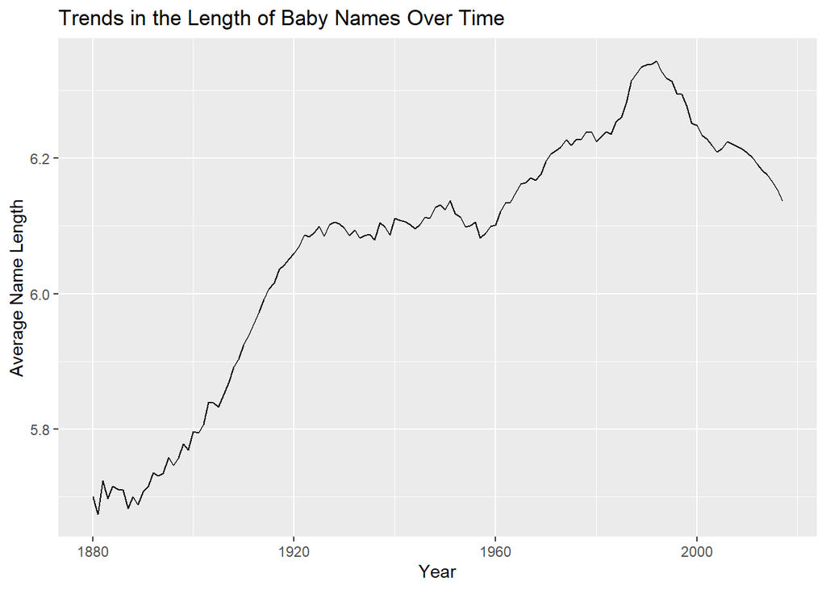

```r
#Part 1
library(babynames)
babynames1 <- babynames |>
  group_by(year) |>
  mutate(average_name_length = mean(nchar(name)))

ggplot(data = babynames1, aes(x = year, y = average_name_length)) +
  geom_line() +
  labs(x = "Year", y = "Average Name Length") +
  ggtitle("Trends in the Length of Baby Names Over Time")
```

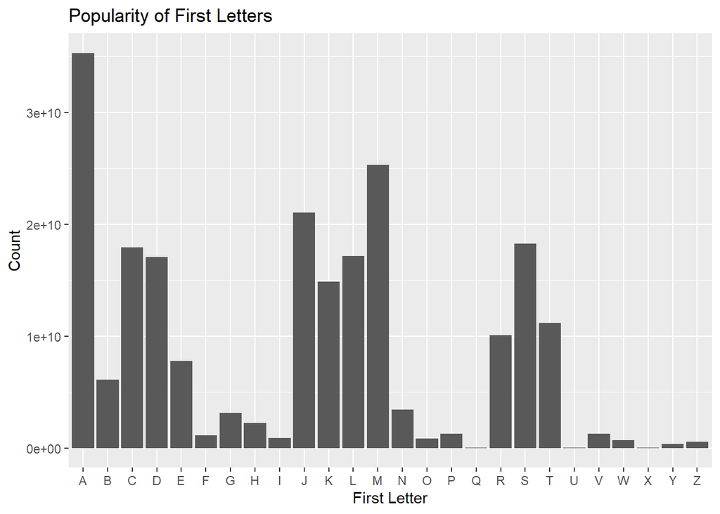

```r
#Part 2
babynames2 <- babynames |>
  mutate(first_letter = str_sub(name, 1, 1),
         last_letter = str_sub(name, -1, -1)) |>
  group_by(first_letter) |>
  mutate(first_letter_count = n()) |>
  group_by(last_letter) |>
  mutate(last_letter_count = n())

ggplot(data = babynames2, aes(x = first_letter, y = first_letter_count)) +
  geom_bar(stat = "identity") +
  labs(x = "First Letter", y = "Count") +
  ggtitle("Popularity of First Letters")
```

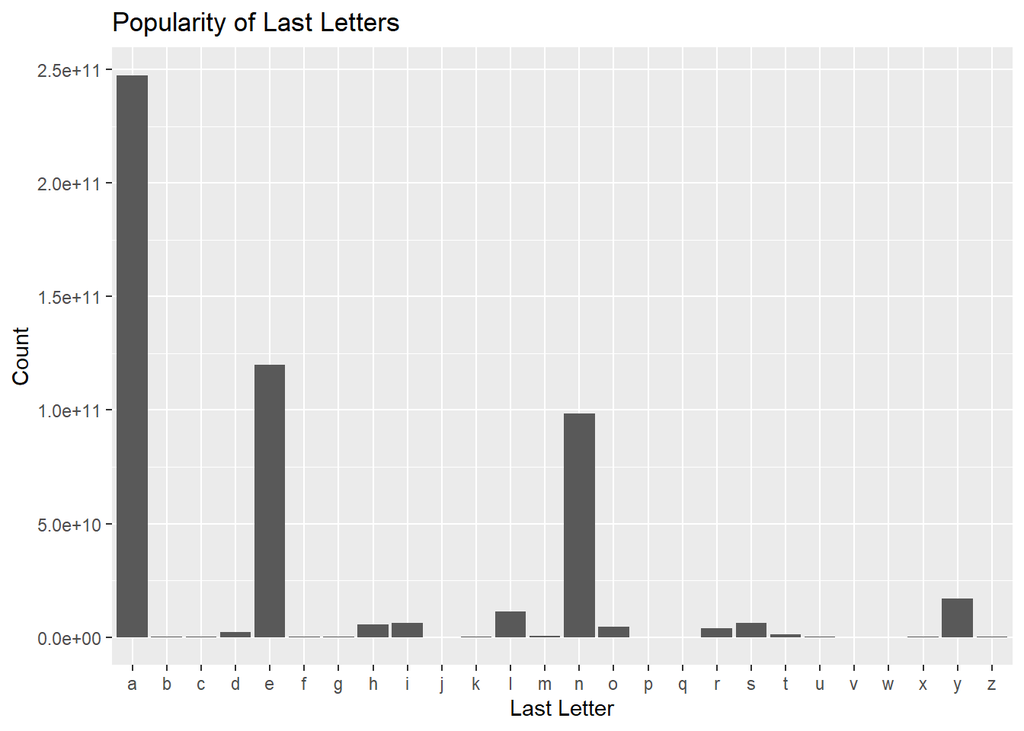

```r
ggplot(data = babynames2, aes(x = last_letter, y = last_letter_count)) +
  geom_bar(stat = "identity") +
  labs(x = "Last Letter", y = "Count") +
  ggtitle("Popularity of Last Letters")
```

## 15.6 Non-English text

### 15.6.1 Encoding

-encoding = () add certain names of languages.

### 15.6.2 Letter variations

-Working in languages with accents poses a significant challenge when determining the position of letters (e.g., with str_length() and str_sub())

-Note that a comparison of these strings with == interprets these strings as different, while the handy str_equal() function in stringr recognizes that both have the same appearance

-locale = can help adapt different languages’ unique formats.

# 16 Regular expressions

## 16.1 Introduction

```r
library(tidyverse)
library(babynames)
```

## 16.3 Key functions

### 16.3.1 Detect matches

-str_detect() returns a logical vector that is TRUE if the pattern matches an element of the character vector and FALSE otherwise

### 16.3.2 Count matches

-str_count()tells you how many matches there are in each string.

- str_to_lower() convert words to lower case.

### 16.3.3 Replace values

-str_replace() replaces the first match, and as the name suggests, str_replace_all() replaces all matches

-str_remove() and str_remove_all() are handy shortcuts for str_replace(x, pattern, ““)

### 16.3.4 Extract variables

-To extract this data using separate_wider_regex() we just need to construct a sequence of regular expressions that match each piece. If we want the contents of that piece to appear in the output, we give it a name. “separate_wider_regex( str, patterns = c(”<“, name =”[A-Za-z]+“,”>-“, gender =”.”, “_“, age =”[0-9]+” ) )”

### 16.3 Exercises (warn)

1.What baby name has the most vowels? What name has the highest proportion of vowels? (Hint: what is the denominator?)

```r
#Baby name with the most vowels
babynames |>
  mutate(vowel_count = str_count(name, "[aeiouAEIOU]")) |>
  filter(vowel_count == max(vowel_count)) |>
  distinct(name)
```

```
## # A tibble: 2 × 1
##   name
##   <chr>
## 1 Mariaguadalupe
## 2 Mariadelrosario
```

```r
#Baby name has the highest proportion of vowels
babynames |>
  mutate(vowel_count = str_count(name, "[aeiouAEIOU]"))|>
  mutate(vowel_proportion = vowel_count / nchar(name)) |>
  filter(vowel_proportion == max(vowel_proportion)) |>
  select(name, vowel_proportion)
```

```
## # A tibble: 110 × 2
##    name  vowel_proportion
##    <chr>            <dbl>
##  1 Eua                  1
##  2 Eua                  1
##  3 Eua                  1
##  4 Eua                  1
##  5 Ea                   1
##  6 Ai                   1
##  7 Ai                   1
##  8 Ai                   1
##  9 Ia                   1
## 10 Ai                   1
## # ℹ 100 more rows
```

2.Replace all forward slashes in “a/b/c/d/e” with backslashes. What happens if you attempt to undo the transformation by replacing all backslashes with forward slashes? (We’ll discuss the problem very soon.)

```r
original<- "F/-/1/5/E"
replaced<- gsub("/", "\\", original)
undo_string <- gsub("\\\\", "/", replaced)
replaced
```

```
## [1] "F-15E"
```

```r
undo_string
```

```
## [1] "F-15E"
```

-Nothing changes when attempted to undo the transformation by replacing all backslashes with forward slashes.

3.Implement a simple version of str_to_lower() using str_replace_all().

4.Create a regular expression that will match telephone numbers as commonly written in your country.

```r
x <- c("13562475567")
str_view(x, "\\d{3}-\\d{4}-\\d{4}")
```

## 16.4 Pattern details

### 16.4.1 Escaping

-We use strings to represent regular expressions, and is also used as an escape symbol in strings. So to create the regular expression . we need the string “\.”

### 16.4.2 Anchors

-Anchor the regular expression using ^ to match the start or $ to match the end

-To force a regular expression to match only the full string, anchor it with both ^ and $

### 16.4.3 Character classes

-There are many pairs for characters(cannot remember them all by now).

### 16.4.4 Quantifiers

-{n} matches exactly n times.

-{n,} matches at least n times.

-{n,m} matches between n and m times.

### 16.4.5 Operator precedence and parentheses

-quantifiers have high precedence and alternation has low precedence which means that ab+ is equivalent to a(b+), and ^a|b$ is equivalent to (^a)|(b$). ### 16.4.6 Grouping and capturing